# Wine Quality Exploration by Ming Fang

25 october 2017

# main question:

Which chemical properties influence the quality of white wines?

# 1: install the file and library

```
## [1] "C:/Users/fangming/Desktop/udacity/EDA/wine_quality_R"
```

```
## [1] 4898   13
```

# 2: Data review

## 2.1 Brief observation

```
##  [1] "X"                    "fixed.acidity"        "volatile.acidity"
##  [4] "citric.acid"          "residual.sugar"       "chlorides"
##  [7] "free.sulfur.dioxide"  "total.sulfur.dioxide" "density"
## [10] "pH"                   "sulphates"            "alcohol"
## [13] "quality"
```

```
## [1] 4898   13
```

```
##        X        fixed.acidity    volatile.acidity  citric.acid
##  Min.   :   1   Min.   : 3.800   Min.   :0.0800   Min.   :0.0000
##  1st Qu.:1225   1st Qu.: 6.300   1st Qu.:0.2100   1st Qu.:0.2700
##  Median :2450   Median : 6.800   Median :0.2600   Median :0.3200
##  Mean   :2450   Mean   : 6.855   Mean   :0.2782   Mean   :0.3342
##  3rd Qu.:3674   3rd Qu.: 7.300   3rd Qu.:0.3200   3rd Qu.:0.3900
##  Max.   :4898   Max.   :14.200   Max.   :1.1000   Max.   :1.6600
##  residual.sugar     chlorides       free.sulfur.dioxide
##  Min.   : 0.600   Min.   :0.00900   Min.   :  2.00
##  1st Qu.: 1.700   1st Qu.:0.03600   1st Qu.: 23.00
##  Median : 5.200   Median :0.04300   Median : 34.00
##  Mean   : 6.391   Mean   :0.04577   Mean   : 35.31
##  3rd Qu.: 9.900   3rd Qu.:0.05000   3rd Qu.: 46.00
##  Max.   :65.800   Max.   :0.34600   Max.   :289.00
##  total.sulfur.dioxide    density             pH          sulphates
##  Min.   :  9.0        Min.   :0.9871   Min.   :2.720   Min.   :0.2200
##  1st Qu.:108.0        1st Qu.:0.9917   1st Qu.:3.090   1st Qu.:0.4100
##  Median :134.0        Median :0.9937   Median :3.180   Median :0.4700
##  Mean   :138.4        Mean   :0.9940   Mean   :3.188   Mean   :0.4898
##  3rd Qu.:167.0        3rd Qu.:0.9961   3rd Qu.:3.280   3rd Qu.:0.5500
##  Max.   :440.0        Max.   :1.0390   Max.   :3.820   Max.   :1.0800
##     alcohol         quality
##  Min.   : 8.00   Min.   :3.000
##  1st Qu.: 9.50   1st Qu.:5.000
##  Median :10.40   Median :6.000
##  Mean   :10.51   Mean   :5.878
##  3rd Qu.:11.40   3rd Qu.:6.000
##  Max.   :14.20   Max.   :9.000
```

The wine dataset consists of 13 variables, with almost 4898 observations. These variables also includes the quality. The main goal of this analysis is to figure out the relationship between different paramterts with wine quality.

## 2.2 Scatterplot matrices

```
##  [1] "fixed.acidity"        "volatile.acidity"     "citric.acid"
##  [4] "residual.sugar"       "chlorides"            "free.sulfur.dioxide"
##  [7] "total.sulfur.dioxide" "density"              "pH"
## [10] "sulphates"            "alcohol"              "quality"
```

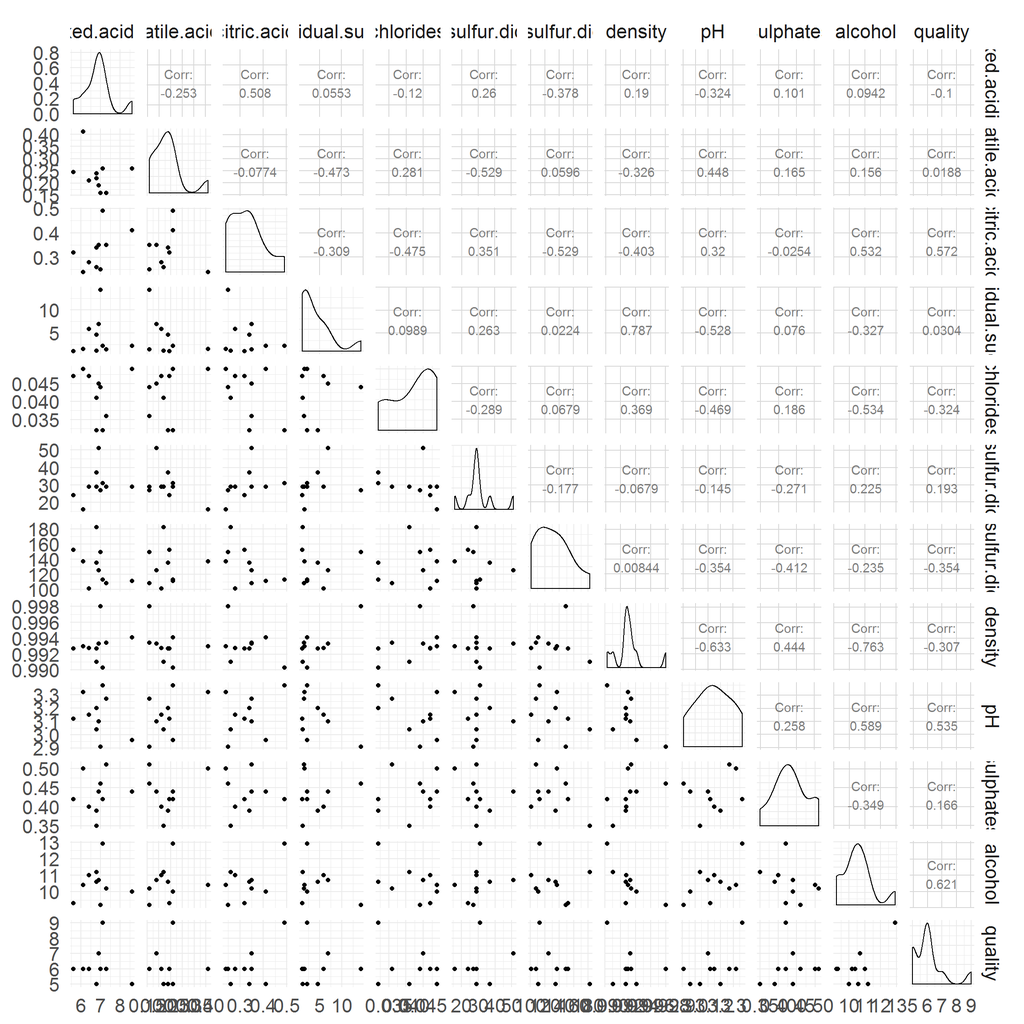

# 3: Univariate Plots Section

## 3.1 Acidity analysis

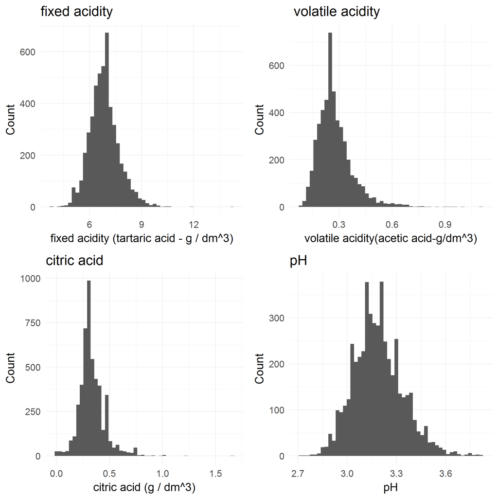

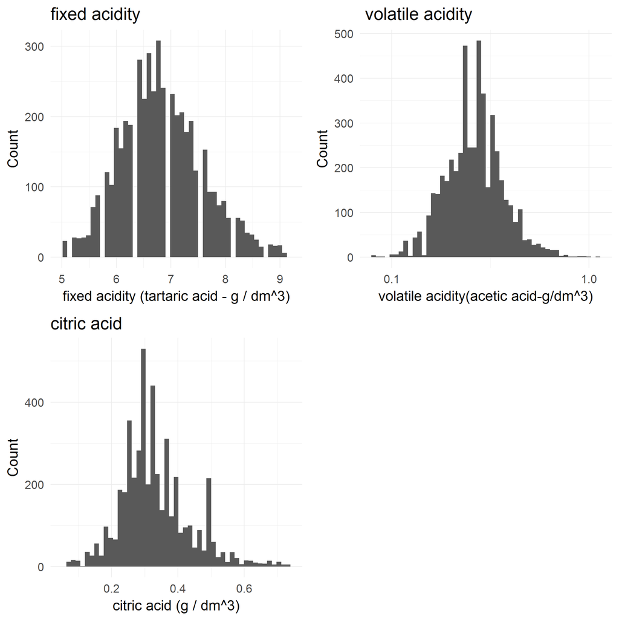

The histogram of these four variables correlated with acidity, which includes volatile.Acidity, citric.Acid, pH, and fixed.Acidity, are plotted. Some histrograms have a long tail. Transforming the long tail data by log x axis or remove some outliers is performed to get a better understanding of the distribution of those data. From the histogram, we can see the distribution of volatile. Acidity, citric. Acid, pH, fixed.Acidity are close to the normal distribution.

## 3.2 quality analysis

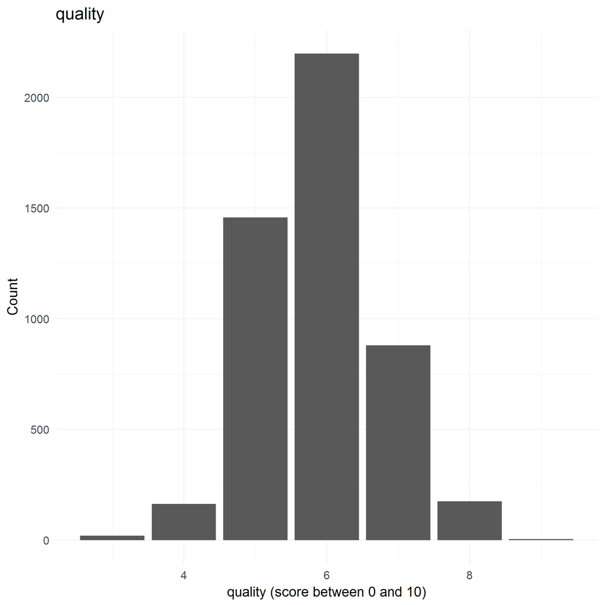

```
##    Min. 1st Qu.  Median    Mean 3rd Qu.    Max.
##   3.000   5.000   6.000   5.878   6.000   9.000
```

Quality is a key parameter in this study. From the histrogram, it demonstrates a normal distribution. We can see that the quality distribution range from 3 to 9 with a median value around 6.

## 3.3 other analysis

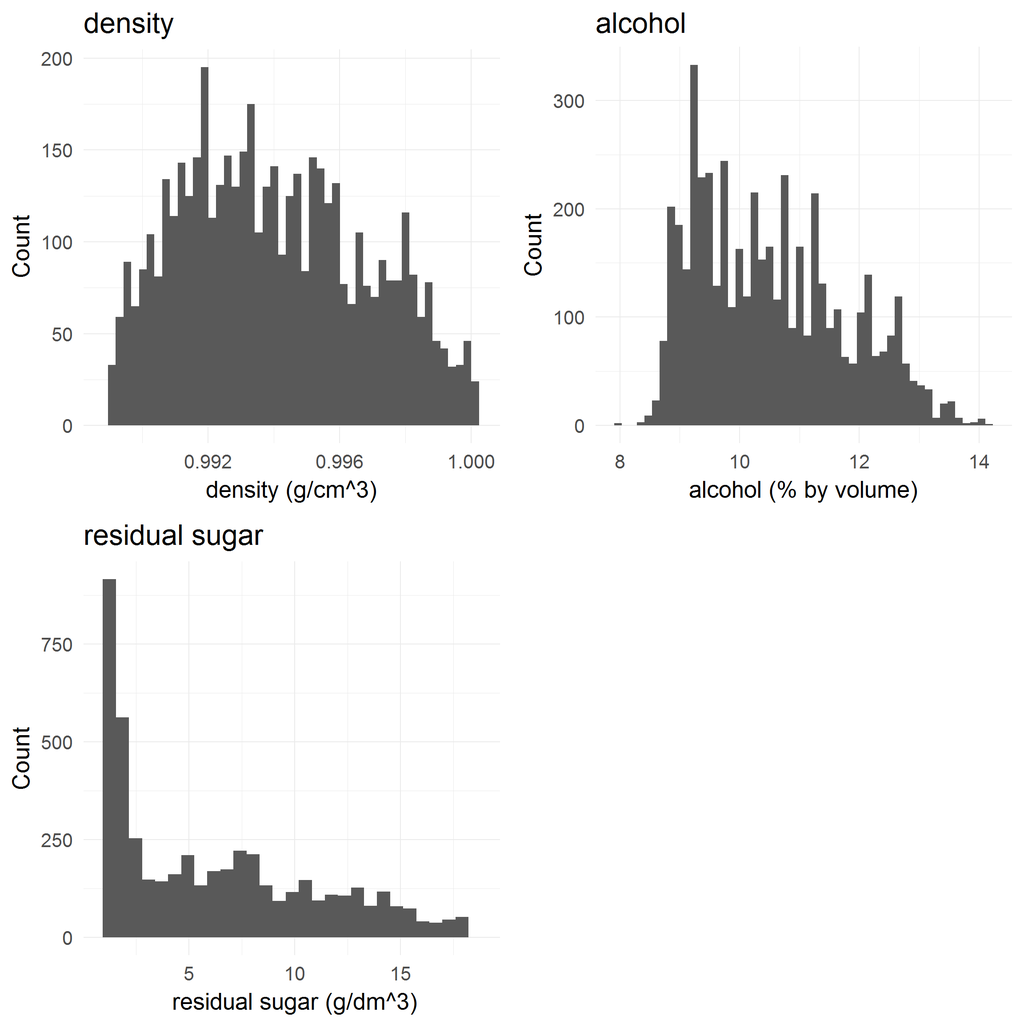

Here we analysis the distribution of other three important variables including density, alcohol and residual.Sugar. From the histogram of density, the density distribution is very shallow, which range from 0.9 to 1.0. From the histogram of alcohol, it looks like two modes exist in the distribution. From the histogram of residual.Sugar, it looks like the distribution is skewed. These three distribution is very interesting, which should be pay attention in the further analysis.

# 4: Biivariate Plots Section

## 4.1: acidity vs quality

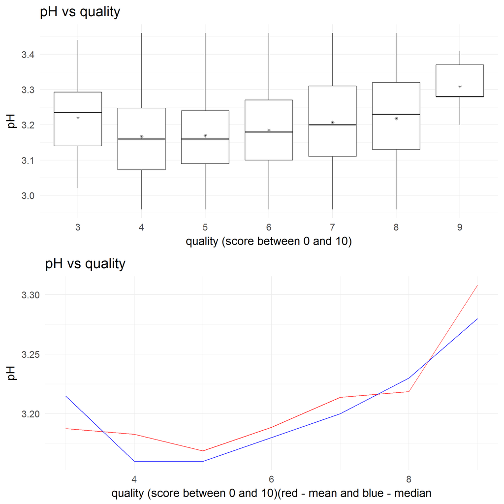

From this analysis, we can see that higher PH number indicate a higher quality. The quality 3 case is a exception. But since the sample number of quality 3 is very small. So a larger error might exist in the data of quality 3.

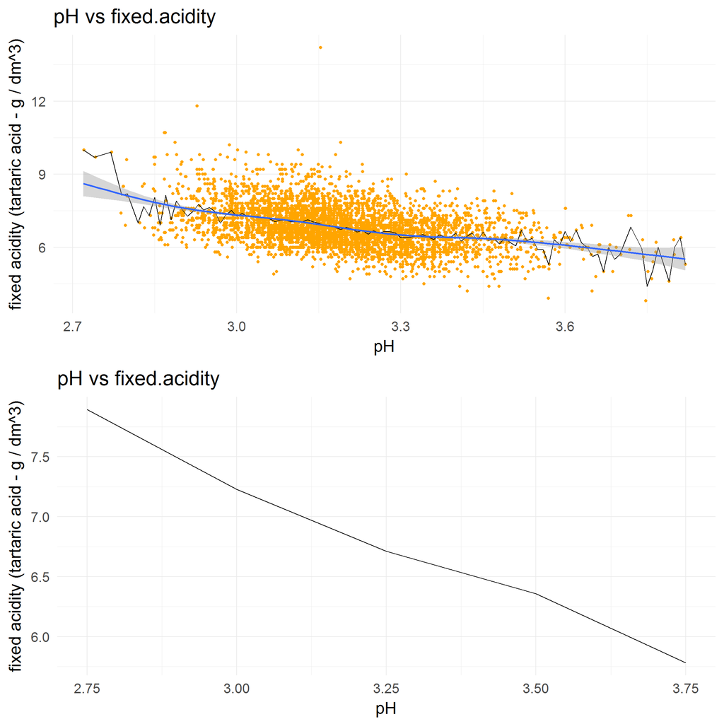

```
## [1] -0.4258583
```

Since the PH value is a measurment of acidity. So how was the acidity corrlated with the pH. From the above graph, it is concluded that the higher fixed acidity, the smaller pH number.

```
## [1] -0.03191537
```

```
## [1] -0.1637482
```

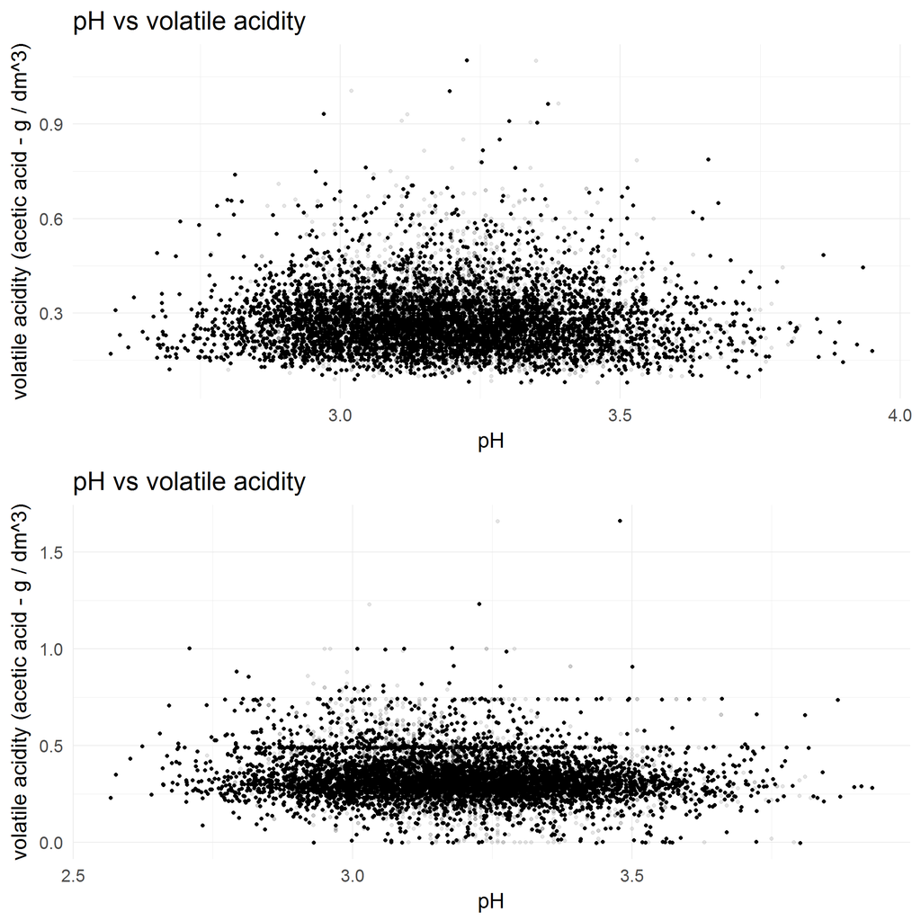

But from the above plot, the pH do not have very clear relationship with citric acid and voltaile acidity.

## 4.2: residual.sugar vs quality

[figure not shown]

## 4.3: chlorides vs quality

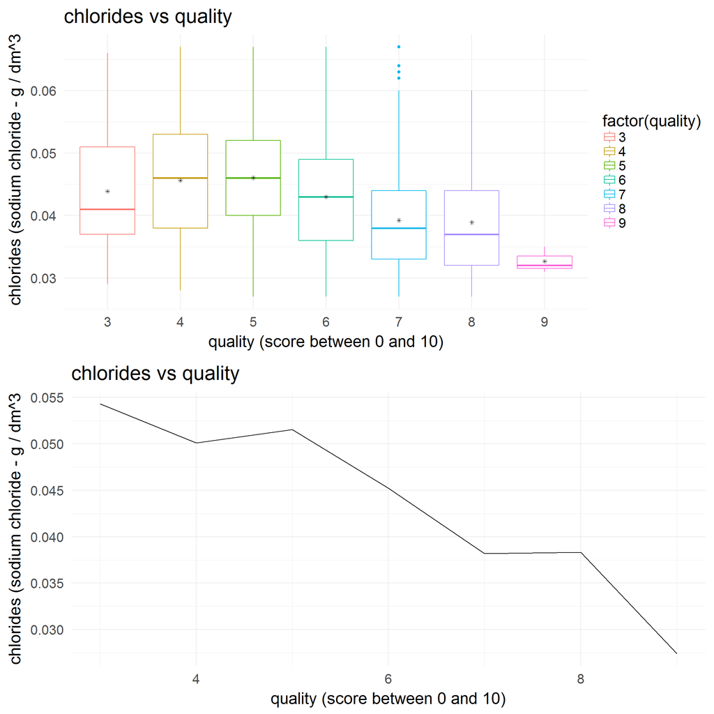

```
## # A tibble: 6 x 3
##   quality chlorides_mean     n
##     <int>          <dbl> <int>
## 1       3     0.05430000    20
## 2       4     0.05009816   163
## 3       5     0.05154633  1457
## 4       6     0.04521747  2198
## 5       7     0.03819091   880
## 6       8     0.03831429   175
```

```
## [1] -0.2099344
```

From these two graph, we can see that the higher quality for the wine, there has less chlorides in the wine.

## 4.4: dioxide vs quality

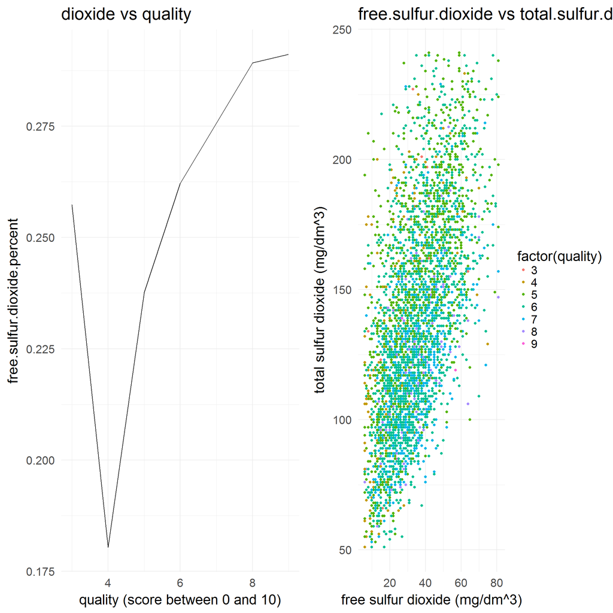

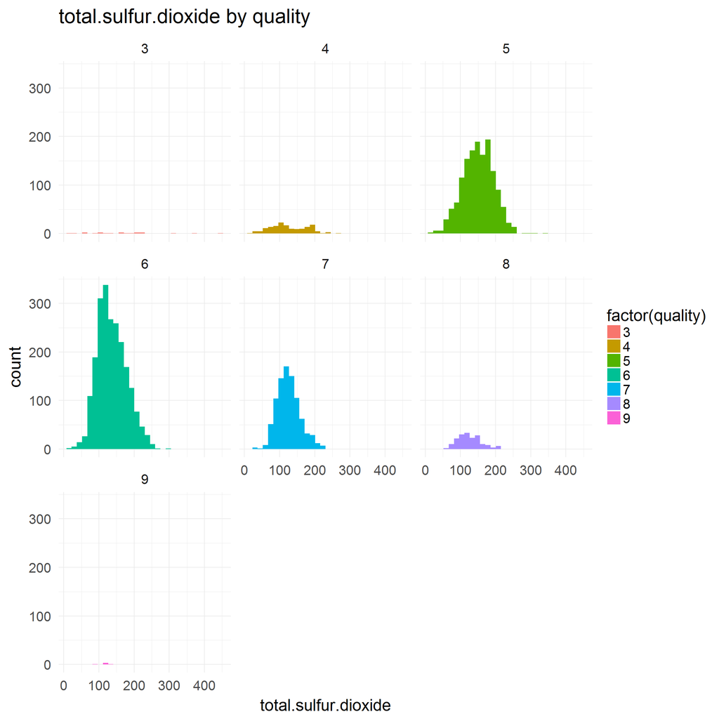

From the analysis, we creat a new variable-free.sulfur.dioxide.percent. From the analysis, we can see quality has a positive relationship with such variable, except the quality3. That might results from that there has a relatively small samples in the quality 3. Beside that, we can also observe that the free fulful dioxide has a positive relation ship with total sulfur dioxide.

## 4.5: residual.sugar vs density

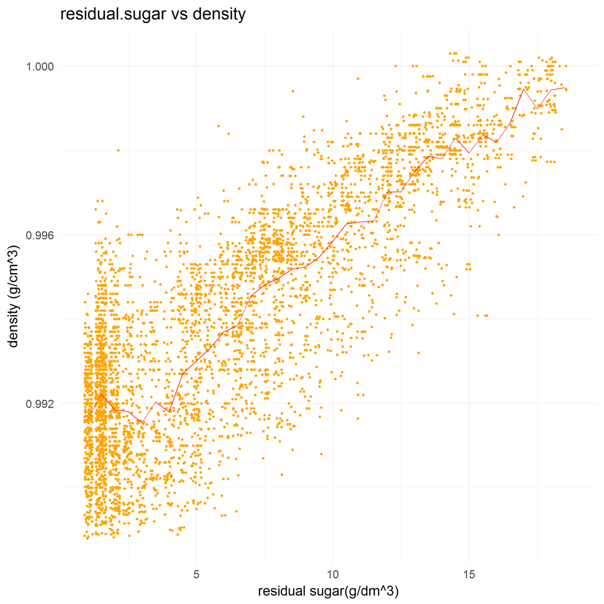

```
##
## Call:
## lm(formula = I(density) ~ I(residual.sugar), data = winedata)
##
## Coefficients:
##       (Intercept)  I(residual.sugar)
##         0.9908654          0.0004947
```

Based on the simulation, we can see that such relation ship is linear.

## 4.5: quality vs density

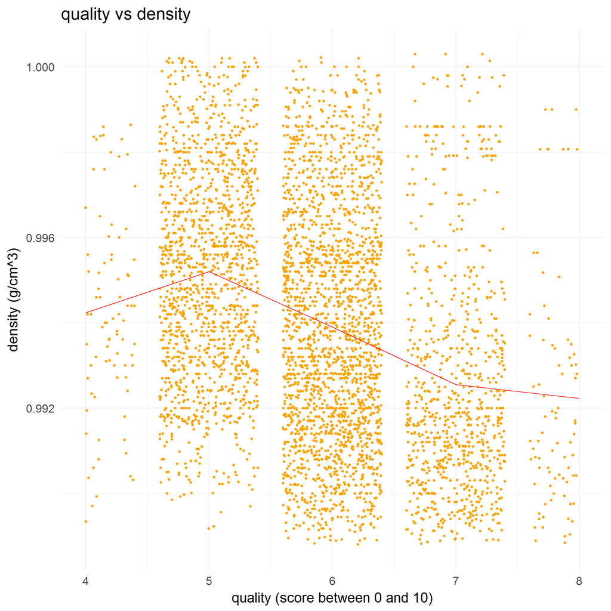

From this plot, we can see that the higher quality wine has less mean value of the density.

# 5. Multivariate Plots Section

## 5.1. alcohol parameter

```
##    Min. 1st Qu.  Median    Mean 3rd Qu.    Max.
##    8.00    9.50   10.40   10.51   11.40   14.20
```

```
##
##  (0,10] (10,12] (12,20]
##    2085    2102     711
```

since we think there has two modes in the histogram of alcohol, so I cut the alcohol into three small regions based on the histogram distribution.

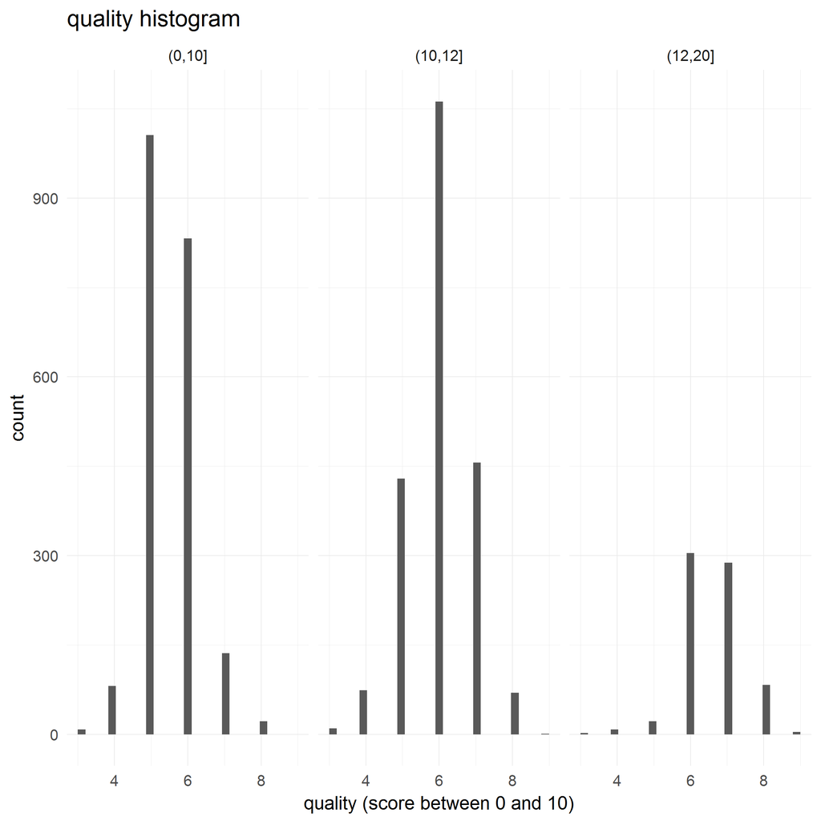

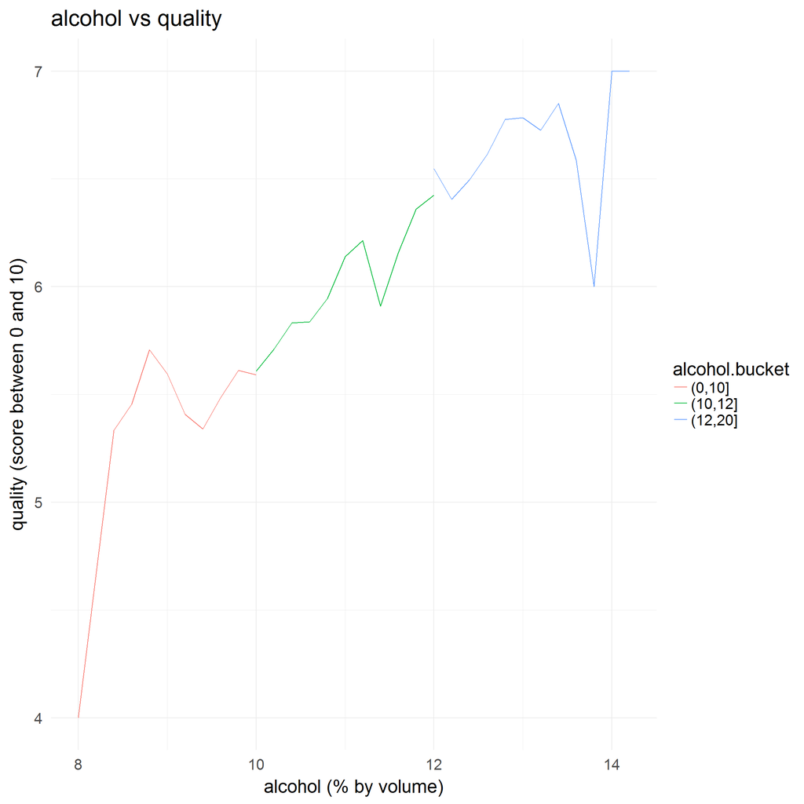

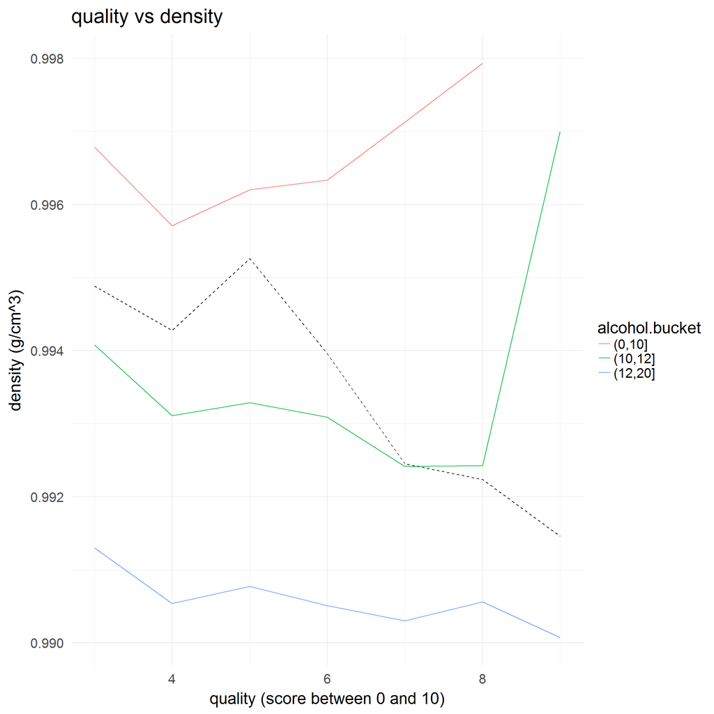

From above graphs,the quality distribution is different within different alcohol range. Within the low alcohol range, the median value is low than 6. within the high alcohol range, the median of quality distribtion is higher than 6. From second graph, it can be ovserved that the relationship between density with quality is different while the alcohol range is different. Besides that, the plot demostrates that a low density indicates a higher alcohol.

## 5.2. pH vs fixed.acidity in different quality range

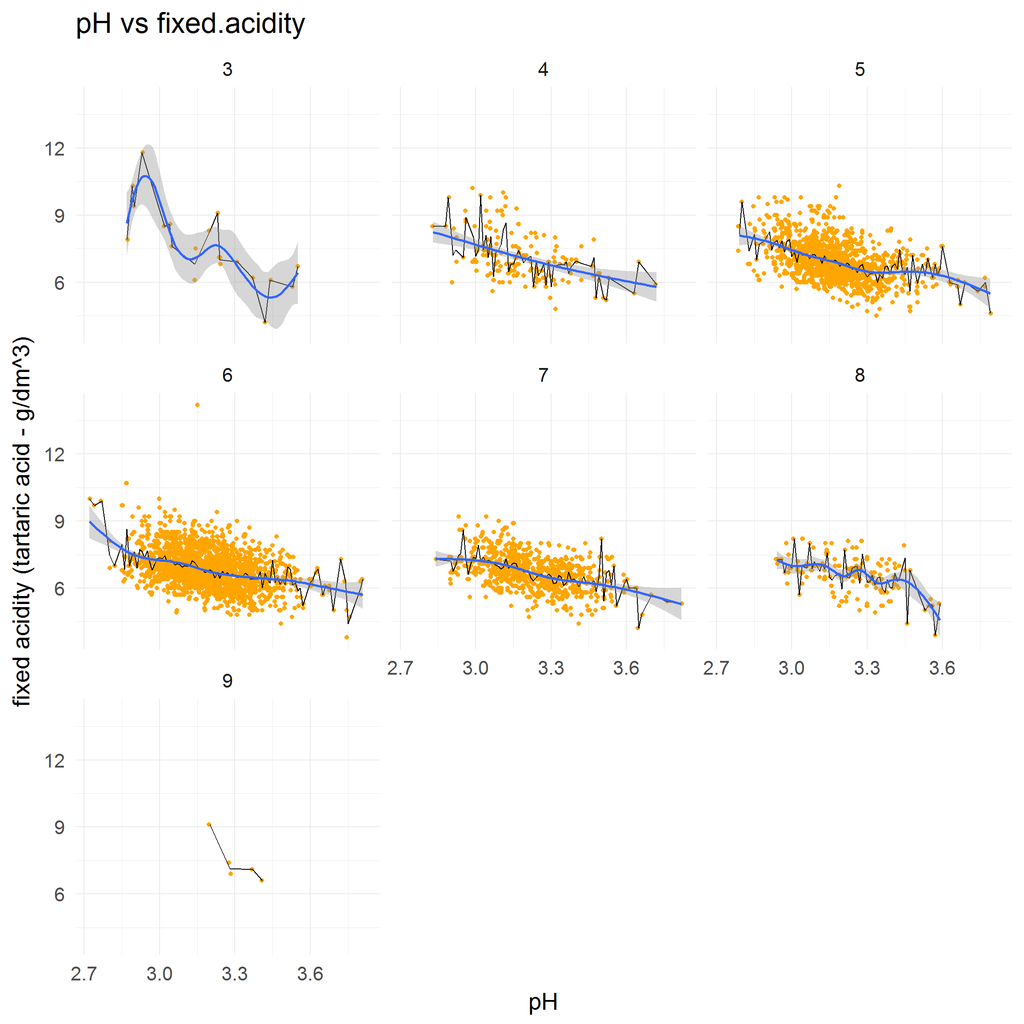

From this graph, it illustrates that the pH has a negative correlation with the fixed.acidity value. When the quality is 3, there has some funny realationship. It results from the small sample number in quality 3.

# 6. Final Plots and Summary

## 6.1 plot 1

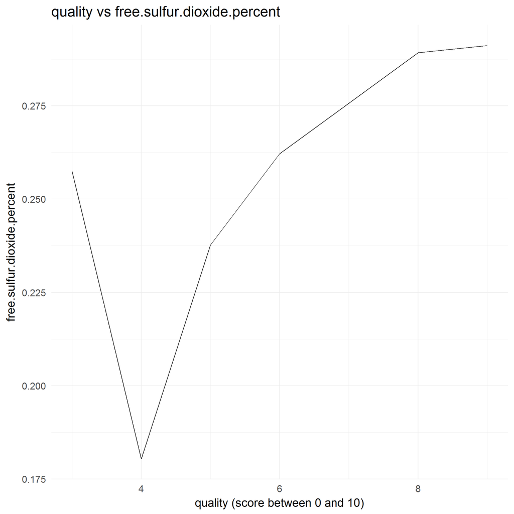

## 6.2 plot 2

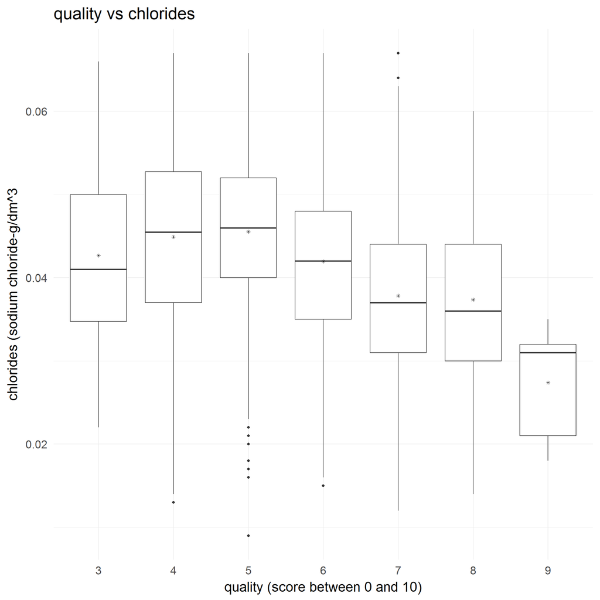

## 6.3 plot 3

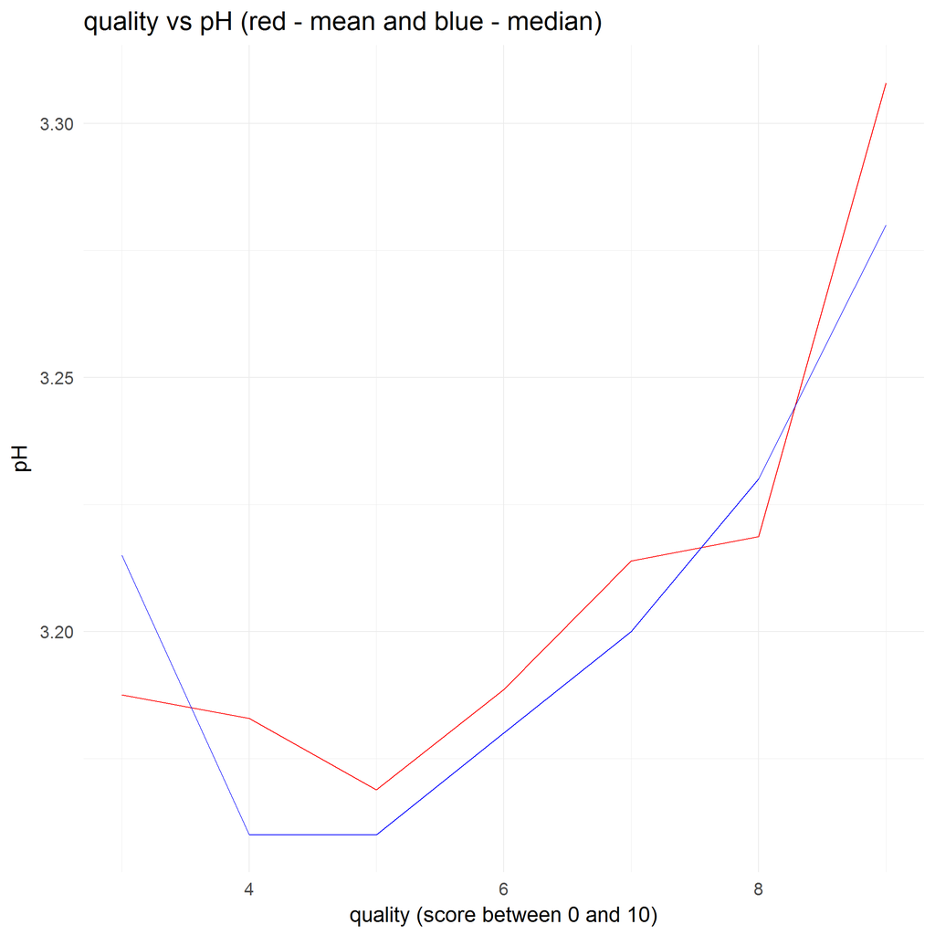

In this part, I select three plots which show the relationship between free.sulfur.dioxide.percent, pH, chlorides with quality. From the above analysis, these three relationship has a strong relation ship with quality.

## 6.4 predict model

From the analysis, I think the pH, chlorides, free.sulfur.dioxide.percent, fixed.acidity, alcohol has a stong relation ship with quality. Since pH has a strong corrlation with fixed.acidity. we do not need to consider fixed.acidity in model. Based on these analysis, I built a model here and predict the quality based on some this model.

```
##       fit      lwr      upr
## 1 5.65792 4.373287 6.942553
```

# 7. Reflection

Based on the analysis, the pH, chlorides, free.sulfur.dioxide.percent, fixed.acidity, alcohol has a stong relation ship with quality. The predictive model is built based on the corrlationship.

when I start to analyze the data, I found there has so many variables. It is very difficult to identify the relationship between each variables and how each variable corrlates with the quality. But the Scatterplot is a good start. From this, a brief observation of the data can be made, which provides a good clue for further analysis. Besides that, histogram is a good start to understand the each variables.

I also notice about that the data has some noise. It is very important to apply the mean() and median() method to obtain a more accurate undersanding about the data. With such method, some noise issue could be resolved.

For the fugure work, I think the procedure to analyse such data should follow below steps: 1: obtain a brief overreview about the data by the scatterplot 2: develop code to plot the histogram of each variables and find the potential trend 3: build corrlations between each selected variable with key result 4: build model to summarize the results and use predictive result to prove the model accuracy